# R Notebook

```r
#Sys.setenv(OMPATH=”/Users/smonti/Google\ Drive/BS831”)
Sys.setenv(OMPATH='/Users/carolmuriithi/Google\ Drive/BS831')
OMPATH <- Sys.getenv("OMPATH")
require(Biobase)
require(limma)
```

```r
#Data Load & Preprocessing
#We first load the CPM (count per million)-normalized data
## read CPM data
CPM <- readRDS( file.path(OMPATH,"data/HNSC_htseq_normalized_AEvsG1vsG3.RDS") )
## show the distribution of 'grades'
table(CPM$grade)
```

```
AE g1 g3
40 40 40
```

```r
## show the distribution of 'stages'
table(CPM$stage)
```

```
       AE   stage i  stage ii stage iii  stage iv
       40         3        17        15        45
```

```r
## simplify stage by grouping categories (i,ii,iii -> lo; iv -> hi)
stage <- factor(c("AE","stage.lo","stage.lo","stage.lo","stage.hi")[CPM$stage],
                levels=c("AE","stage.lo","stage.hi"))
CPM$stage <- stage
## look at the "cross-stratification" of grade and stage
table(CPM$grade,CPM$stage)
```

```
     AE stage.lo stage.hi
  AE 40        0        0
  g1  0       22       18
  g3  0       13       27
```

## Exercise 1: Pathway Enrichment Analysis

You are asked to carry out geneset enrichment analysis with respect to the phenotype “g1 vs. g3” using the hallmark geneset compendium from MSigDB. Save the results object in the file final.exercise1.RDS.

read.gmt function Let us define a simple read.gmt function to … read a ‘.gmt’ file. There are probably smarter (more elegant) ways. Anybody?

```r
read.gmt.sample <- function( gmt.file ) {
    gmt <- scan(gmt.file,"character",sep="\n")
    gmt <- lapply(gmt,function(Z) unlist(strsplit(Z,"\t"))[-2])
    names(gmt) <- sapply(gmt,function(Z) Z[1])
    gmt <- lapply(gmt,function(Z) Z[-1])
}
hall <- read.gmt.sample( file.path(OMPATH,"data/h.all.v6.1.symbols.gmt") )
```

```
Read 50 items
```

```r
print(head(names(hall))) # show first few genesets
```

```
[1] "HALLMARK_TNFA_SIGNALING_VIA_NFKB"    "HALLMARK_HYPOXIA"
[3] "HALLMARK_CHOLESTEROL_HOMEOSTASIS"    "HALLMARK_MITOTIC_SPINDLE"
[5] "HALLMARK_WNT_BETA_CATENIN_SIGNALING" "HALLMARK_TGF_BETA_SIGNALING"
```

# Preparing the data Next, we extract the samples corresponding to grades g1 and g3 only. We also log2-transform the data.

```r
g1vsg3 <- CPM[,CPM$grade %in% c("g1","g3")]
g1vsg3$grade <- droplevels(g1vsg3$grade)
exprs(g1vsg3) <- log2(exprs(g1vsg3)+1)
```

# Compute gene ranking based on t.test

```r
ttest <- as.data.frame(
  t(apply(exprs(g1vsg3),1,
          function(y) {
            out <- t.test(y~as.factor(g1vsg3$grade))
            c(score.t=out$statistic, pval=out$p.value)
            })))
```

```r
ttest.order<-ttest[order(ttest$score.t),]
head(ttest.order)
```

|  | score.t.t | pval |
| --- | --- | --- |
| ENSG00000149179 | -6.521381 | 6.550340e-09 |
| ENSG00000185010 | -6.371994 | 1.225647e-08 |
| ENSG00000143570 | -6.358244 | 1.317034e-08 |
| ENSG00000139354 | -5.940013 | 8.905527e-08 |
| ENSG00000235106 | -5.930666 | 8.344201e-08 |
| ENSG00000113504 | -5.903895 | 8.783936e-08 |

# ks.genescore

```r
source( file.path(OMPATH,"code/ksGenescore.R") )
```

```r
ttest.order$ensembl_gene_id<-rownames(ttest.order)
```

```r
test<-merge(ttest.order, fData(g1vsg3)[,c("ensembl_gene_id","hgnc_symbol")],  by="ensembl_gene_id")
```

```r
test.order<-test[order(test$score.t),]
```

```r
N<-nrow(ttest.order) # total number of gene
```

```r
 KShall <- data.frame(ks.score=double(), p.value=double())
   N<-nrow(ttest.order)
for (i in 1:50){
   unlist<-unlist(hall[i])
   index<-match(unlist, test.order$hgnc_symbol)
   h<-na.omit(sort(index))


   KSoutput<-ksGenescore(N, h, do.plot = F)

   KShall[i,1] <-as.numeric(KSoutput$statistic)
   KShall[i,2] <-KSoutput$p.value
   rownames(KShall)[i]<-names(hall)[i]

}
```

```r
KShall$q.value <- p.adjust(KShall$p.value, method="BH")
```

```r
#KShall$q.value <- p.adjust(KShall$p.value,method="BH")
#rownames(KShall) <- gsub("HALLMARK_","",rownames(KShall))
#save(KShall,file=file.path(SCCPATH,"<student id>/final.exercise1.RDS"))
#print(head(KShall))
rownames(KShall) <- gsub("HALLMARK_","",rownames(KShall))
#save(KShall,file=file.path(SCCPATH,"<student id>/final.exercise1.RDS"))
#saveRDS(limmaRes0, file=file.path("/Users/carolmuriithi/","homework2_limmaRes0.RDS"))
save(KShall,file=file.path("/Users/carolmuriithi/", "/final.exercise1.RDS"))
print(head(KShall))
```

|  | ks.score | p.value | q.value |
| --- | --- | --- | --- |
| TNFA_SIGNALING_VIA_NFKB | -0.09377664 | 6.491735e-02 | 1.047054e-01 |
| HYPOXIA | 0.09247495 | 7.015422e-02 | 1.096160e-01 |
| CHOLESTEROL_HOMEOSTASIS | -0.17695556 | 2.088098e-02 | 3.728746e-02 |
| MITOTIC_SPINDLE | 0.28324422 | 4.485301e-14 | 7.475502e-13 |
| WNT_BETA_CATENIN_SIGNALING | 0.24577720 | 1.259054e-02 | 2.623029e-02 |
| TGF_BETA_SIGNALING | 0.10477795 | 5.947058e-01 | 6.464194e-01 |

# Gene Filtering

Next, filter out genes with mostly zero counts. We perform zero filtering by ‘recycling’ the script defined in the Rmodule_DiffanalRNAseq module.

```r
#Gene Filtering
## Remove those genes without at least 1 read per million in at least
## 'n' samples, where n is the number of samples in the 'smallest'
## phenotype class
removeLowExpression <- function(eset, class_id, min.thresh=0)
{
  groups <- pData(eset)[,class_id]
  min.samples <-
    max(min.thresh,min( sapply(levels(groups), function(x){length(which(groups %in% x))})))
  rpm <- colSums(exprs(eset))/1000000
  filter_ind <- t(apply(exprs(eset), 1,function(x) {x >rpm}))
  filter_ind_rowsums <- apply(filter_ind, 1, sum)
  return(eset[filter_ind_rowsums > min.samples,])
}
CPM1 <- removeLowExpression(eset=CPM, class_id="grade", min.thresh=4)
print(dim(CPM1))
```

```
Features  Samples
   14329      120
```

## Take 2 delete

```r
## Remove those genes without at least 1 read per million in at least
## 'n' samples, where n is the number of samples in the 'smallest'
## phenotype class
removeLowExpression <- function(eset, class_id, min.thresh=0)
{
  groups <- pData(eset)[,class_id]
  min.samples <-
    max(min.thresh,min( sapply(levels(groups), function(x){length(which(groups %in% x))})))
  rpm <- colSums(exprs(eset))/1000000
  filter_ind <- t(apply(exprs(eset), 1,function(x) {x >rpm}))
  filter_ind_rowsums <- apply(filter_ind, 1, sum)
  return(eset[filter_ind_rowsums > min.samples,])
}
CPM1 <- removeLowExpression(eset=CPM, class_id="grade", min.thresh=4)
print(dim(CPM1))
```

```
Features  Samples
   14329      120
```

```r
## let us log-transform the CPM data for subsequent handling
exprs(CPM1) <- log2(exprs(CPM1)+1)
```

# Exercise 2: Testing for Normality of Gene Distributions

Next, we test the normality of the CPM-normalized data using ks.test (remember that the data is log2-transformed).

In this exercise, you are asked to test each gene for its deviation from normality by ks.test, and store the results in a data.frame to be saved to final.exercise2.RDS.

Here, we show the test applied to a single gene.

```r
## remember how you can use ks.test to test the difference btw two distributions
ks.test( exprs(CPM1)[1,], "pnorm", mean=mean(exprs(CPM1)[1,]), sd=sd(exprs(CPM1)[1,]) )
```

```
    One-sample Kolmogorov-Smirnov test

data:  exprs(CPM1)[1, ]
D = 0.05918, p-value = 0.7947
alternative hypothesis: two-sided
```

Apparently, the first gene in the CPM1 dataset does not significantly deviates from normality (p-value = 0.7947).

You are asked to perform the same test on every gene, and to save the output in tabular form. The results to be saved will look as follows.

```r
KStest<-apply(exprs(CPM1), 1,
          function(y) {
            out <- ks.test(unique(y), "pnorm", mean=mean(y), sd=sd(y))
            c(statistic=out$statistic, p.value=out$p.value)}
          )
```

```r
KS<-as.data.frame(t(KStest))
```

```r
KS$q.value <- p.adjust(KS$p.value,method="BH")
```

```r
#saveRDS(KS, file=file.path("C:/Users/poying/Desktop/final.exercise2.RDS"))
#saveRDS(limmaRes0, file=file.path("/Users/carolmuriithi/","homework2_limmaRes0.RDS"))
saveRDS(KS, file=file.path("/Users/carolmuriithi/final.exercise2.RDS"))
print(head(KS))
```

|  | statistic.D | p.value | q.value |
| --- | --- | --- | --- |
| ENSG00000186132 | 0.05917972 | 0.7946696 | 0.9999891 |
| ENSG00000182584 | 0.09707623 | 0.2081087 | 0.7057964 |
| ENSG00000174799 | 0.05768070 | 0.8195025 | 0.9999891 |
| ENSG00000116691 | 0.07468046 | 0.5150208 | 0.9354459 |
| ENSG00000110104 | 0.04381626 | 0.9753268 | 0.9999891 |
| ENSG00000121236 | 0.06289278 | 0.7295334 | 0.9999891 |

## CLUSTERING

Hierarchical Clustering Next, you will be asked to perform hierarchical clustering of the log2-transformed, CPM-normalized data (CPM1) on both samples/columns and genes/rows (see Rmodule_hclust.Rmd).

For this task, let us first drastically filter the genes, say, to ~2000, to make the clustering faster.

```r
source( file.path(OMPATH, "code/variationFilter.R") )
## performing variation filtering in log space ..
CPM2 <- variationFilter(CPM1,ngenes=2000, do.plot=FALSE)
```

```
Variation filtering based on mad .. done.
Selecting top 2000 by mad .. done, 2000 genes selected.
```

## Next, let us perform hierarchical clustering based on hclust with ward.D as the agglomeration rule. You will have to choose the proper distance for each dimension.

```r
distC <- function(x) dist(t(x), method = "euclidean")
distR <- function(x) stats::as.dist(1 - cor(t(x)))
```

```r
distC.matrix<-distC(exprs(CPM2))
distR.matrix<-distR(exprs(CPM2))
```

```r
## clustering (choose the proper distances for the two dimensions - see slides)
hc.col <- hclust( distC.matrix, method="ward.D" )
hc.row <- hclust( distR.matrix, method="ward.D" )
```

```r
source( file.path(OMPATH, "code/misc.R") )
library("pheatmap")
require(pheatmap)
#source( file.path(OMPATH, "code/heatmap.R") )
#require(pheatmap)
#require(heatmap.plus)
```

```r
## expression levels color coding
bwrPalette <- colGradient(c("blue","white","red"),length=13)
## sample annotation color coding
annot <- pData(CPM2)[,c("grade","stage")]
annotCol <- list(
  grade = c("white","green","darkgreen"),
  stage = c("white","green","darkgreen")
)
names(annotCol$grade) <- levels(annot$grade)
names(annotCol$stage) <- levels(annot$stage)
## heatmap visualization
pheatmap(exprs(CPM2),
         color=bwrPalette,
         annotation_col = annot,
         annotation_colors = annotCol,
         cluster_rows=hc.row, # the result of the hclust call above
         cluster_cols=hc.col, # ditto
         show_rownames = FALSE,
         show_colnames = FALSE,
         scale = "row")
```

[output not shown]

## EXERCISE3

```r
C3 <- cutree(hc.col,3)
annot1 <- annot
annotCol1 <- annotCol
annot1$cluster <- factor(C3)
annotCol1$cluster <- c("yellow","orange","purple")
names(annotCol1$cluster) <- levels(annot1$cluster)
pheatmap(exprs(CPM2),
         color=bwrPalette,
         annotation_col = annot1,
         annotation_colors = annotCol1,
         cluster_rows=hc.row,
         cluster_cols=hc.col,
         show_rownames = FALSE,
         show_colnames = FALSE,
         scale = "row")
```

[output not shown]

You now are asked to test for association (or enrichment) of C3 membership with grade and stage by Fisher test.

Below, we show the contingency table, and the summary of the corresponding Fisher test for grade. Notice that the enrichment is highly significant (although not perfect), and that each cluster has an over-representation of one of the three grade categories (“AE”, “g1”, or “g3”).

Here’s the results.

```r
table.grade<-table(C3, CPM2$grade)
table.grade
```

```
C3  AE g1 g3
  1 31  0  0
  2  8 17 38
  3  1 23  2
```

```r
fisher.test(table.grade)
```

```
    Fisher's Exact Test for Count Data

data:  table.grade
p-value < 2.2e-16
alternative hypothesis: two.sided
```

```r
table.stage<-table(C3, CPM2$stage)
table.stage
```

```
C3  AE stage.lo stage.hi
  1 31        0        0
  2  8       22       33
  3  1       13       12
```

```r
fisher.test(table.stage)
```

```
    Fisher's Exact Test for Count Data

data:  table.stage
p-value < 2.2e-16
alternative hypothesis: two.sided
```

## RDS

```r
cluster.grade <- list(cluster1='AE',
                      cluster2='g3',
                      cluster3='g1')
cluster.stage <- list(cluster1='AE',
                      cluster2='stage.hi',
                      cluster3='stage.lo')
#saveRDS(limmaRes0, file=file.path("/Users/carolmuriithi/","homework2_limmaRes0.RDS"))
saveRDS(cluster.grade,file=file.path("/Users/carolmuriithi/", "final.exercise3.grade.RDS"))
saveRDS(cluster.stage,file=file.path("/Users/carolmuriithi/","final.exercise3.stage.RDS"))
```

# EXERCISE 4

```r
source( file.path(OMPATH, "code/hcopt.R") )
require(cba) # load the necessary pacakge
```

```r
ho.col <- hcopt(distC.matrix, method="ward.D" )
ho.row <- hcopt(distR.matrix, method="ward.D" )
```

```r
## expression levels color coding
bwrPalette <- colGradient(c("blue","white","red"),length=13)
## sample annotation color coding
annot <- pData(CPM2)[,c("grade","stage")]
annotCol <- list(
  grade = c("white","green","darkgreen"),
  stage = c("white","green","darkgreen")
)
names(annotCol$grade) <- levels(annot$grade)
names(annotCol$stage) <- levels(annot$stage)
## heatmap visualization
pheatmap(exprs(CPM2),
         color=bwrPalette,
         annotation_col = annot,
         annotation_colors = annotCol,
         cluster_rows=ho.row, # the result of the hclust call above
         cluster_cols=ho.col, # ditto
         show_rownames = FALSE,
         show_colnames = FALSE,
         scale = "row")
```

[output not shown]

In this exercise you are asked to:

compute the distance between every pair of adjacent samples in the ordered dendrogram returned by hclust. compute the distance between every pair of adjacent samples in the ordered dendrogram returned by hcopt. compare the distribution of distances between the two. To perform the computations in 1 (and similarly 2), you will need to use the order returned by hclust (i.e., hc.col$order), and compute the n???1 Euclidean distances between every pair of adjacent samples according to the order (where n is the number of samples).

Below, we show one possible way to compute the distances based on hclust (notice that hc.col is the variable where we saved the corresponding sample clustering results). There might be more elegant ways.

```r
hclust.pairs <- cbind(hc.col$order[-ncol(CPM2)],hc.col$order[-1])
hclust.dist <- apply(hclust.pairs,1,function(X) dist(t(exprs(CPM2)[,X])))
```

```r
hcopt.pairs <- cbind(ho.col$order[-ncol(CPM2)],ho.col$order[-1])
hcopt.dist <- apply(hcopt.pairs,1,function(X) dist(t(exprs(CPM2)[,X])))
```

```r
DIST <- data.frame(hclust=sort(hclust.dist),
                   hcopt=sort(hcopt.dist))
#saveRDS(limmaRes0, file=file.path("/Users/carolmuriithi/","homework2_limmaRes0.RDS"))
#saveRDS(DIST,file=file.path("C:/Users/poying/Desktop/exercise4.RDS"))
saveRDS(DIST, file=file.path("/Users/carolmuriithi/","exercise4.RDS"))
print(head(DIST))
```

|  | hclust | hcopt |
| --- | --- | --- |
| sample241 | 38.52453 | 38.52453 |
| sample447 | 39.83858 | 39.83858 |
| sample080 | 42.93769 | 42.93769 |
| sample344 | 43.66555 | 43.66555 |
| sample200 | 44.84001 | 44.84001 |
| sample166 | 46.14321 | 45.18469 |

```r
DIST <- data.frame(hclust=sort(hclust.dist),
                   hcopt=sort(hcopt.dist))
saveRDS(DIST,file=file.path("C:/Users/poying/Desktop/exercise4.RDS"))
print(head(DIST))
```

[output not shown]

We next plot the sorted distances based on the two orders. As you can see, most distances are larger in the hclust-based ordering than in the hcopt-based ordering, which is to be expected, since hcopt is specifically designed to chose the order that minimizes pairwise adjacent distances.

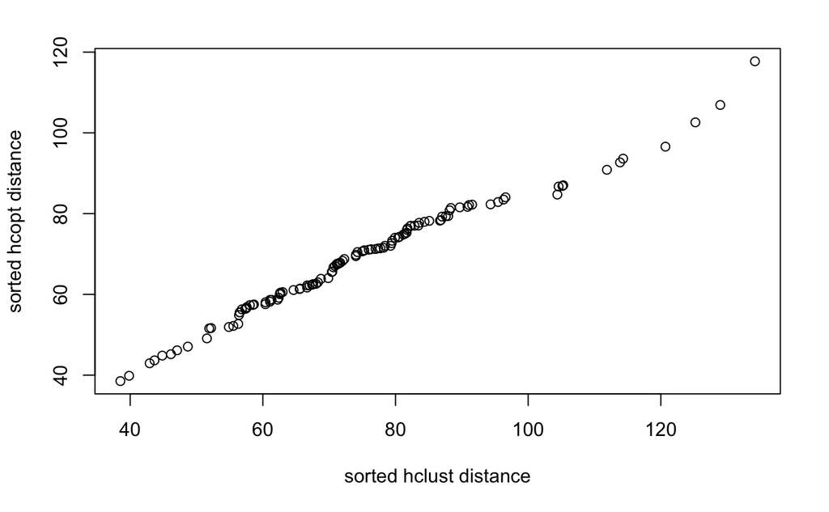

```r
plot(DIST$hclust,DIST$hcopt, xlab="sorted hclust distance",ylab="sorted hcopt distance")
```

## Classification

```r
require(limma)
featureSelect <- function( DAT, CLS, nfeat, balanced=TRUE )
{
  ## BEGIN input checks
  if ( class(DAT)!="ExpressionSet" ) stop( "'ExpressionSet' object expcted: ", class(DAT) )
  if ( length(CLS)!=ncol(DAT) ) stop( "CLS and DAT have incompatible sizes" )
  if ( length(unique(CLS))!=2 ) stop( "CLS must be a binary feature" )
  if ( nfeat<1 | nfeat>nrow(DAT) ) stop( "nfeat must be in [1,nrow(DAT)]" )
  ## END checks

  design= model.matrix(~as.factor(CLS))
  fitTrn <- lmFit(DAT,design)
  fitTrn <- eBayes(fitTrn)
  TT <- topTable(fitTrn,coef=2,number=Inf)

  DAT1 <- {
    if ( balanced ) # pick half markers in each direction
      DAT[c(match(rownames(TT)[order(TT$t,decreasing=TRUE)[1:ceiling(nfeat/2)]],featureNames(DAT)),
            match(rownames(TT)[order(TT$t,decreasing=FALSE)[1:ceiling(nfeat/2)]],featureNames(DAT))),]
    else            # pick top markers irrespective of direction
      DAT[match(rownames(TT)[order(abs(TT$t),decreasing=TRUE)[1:nfeat]],featureNames(DAT)),]
  }
  list(dat=DAT1,tbl=TT[match(featureNames(DAT1),rownames(TT)),])
}
```

```r
set.seed(1)
require(caret)
CPM3<-CPM2
CPM3_notAE <- CPM3[, CPM3$grade != "AE"] # need this?
CPM3_notAE$grade<- droplevels(CPM3_notAE$grade)
```

Create index that split CPM3 into two startified dataset

```r
CPM3_idx <- createDataPartition(CPM3_notAE$grade, p=0.6, list=FALSE, times=1)
CPM3_train <- CPM3_notAE[, CPM3_idx]
CPM3_test <- CPM3_notAE[, -CPM3_idx]
```

Evaluate, by 10-fold cross validation, classifiers based on 20, 50, 100, and 500 balanced features in the training (using the function featureSelect defined above). Use featureSelect to select features on the training set, prior to running cross validation. Note that this method of feature selection prior to performing cross-validation is biased, why? Use a classifier of your choice between RandomForest, Elastic Net, and SVM. You may use the caret package, as shown in class. Feel free to test more than one of the three classifiers, if you wish. Report the summary table with the performance of the different number-of-features/classifiers in terms of area under the ROC curve (AUC), sensitivity, and specificity.

```r
result <- featureSelect(CPM3_train, CPM3_train$grade == "g1", 20)
train_x <- data.frame(t(Biobase::exprs(result$dat)))
train_y <- result$dat$grade
fitControl <- trainControl(method="cv",
                           number=10,
                           classProbs=T,
                           summaryFunction=twoClassSummary)
RF_20 <- train(x=train_x,
             y=train_y,
             method="rf", # random forest
             trControl=fitControl,
             tuneGrid=expand.grid(mtry=c( 5,10,15, 20)),
             metric='ROC')
   #tuneGrid=expand.grid(mtry=c(32, 50, 100, 250, 500)),
```

```r
RF_20
```

```
Random Forest

48 samples
20 predictors
 2 classes: 'g1', 'g3'

No pre-processing
Resampling: Cross-Validated (10 fold)
Summary of sample sizes: 43, 44, 43, 44, 44, 44, ...
Resampling results across tuning parameters:

  mtry  ROC        Sens       Spec
   5    0.8861111  0.7666667  0.9166667
  10    0.8750000  0.7666667  0.8833333
  15    0.8388889  0.7666667  0.8833333
  20    0.8611111  0.7333333  0.8833333

ROC was used to select the optimal model using the largest value.
The final value used for the model was mtry = 5.
```

```r
plot(RF_20, metric = "ROC")
```

[output not shown]

```r
## show the parameters that yield the most accurate classifier (as estimated by cv)
RF_20$bestTune
```

[output not shown]

```r
#final model used and performance across test sets of each fold
RF_20$finalModel
```

[output not shown]

```r
result <- featureSelect(CPM3_train, CPM3_train$grade == "g1", 50)
train_x <- data.frame(t(Biobase::exprs(result$dat)))
train_y <- result$dat$grade
fitControl <- trainControl(method="cv",
                           number=10,
                           classProbs=T,
                           summaryFunction=twoClassSummary)
RF_50 <- train(x=train_x,
             y=train_y,
             method="rf", # random forest
             trControl=fitControl,
             tuneGrid=expand.grid(mtry=c(20, 30, 50)),
             metric='ROC')
   #tuneGrid=expand.grid(mtry=c(32, 50, 100, 250, 500)),
```

```r
RF_50 <- train(x=train_x,
             y=train_y,
             method="rf", # random forest
             trControl=fitControl,
             tuneGrid=expand.grid(mtry=c(20,30, 50)),
             metric='ROC')
   #tuneGrid=expand.grid(mtry=c(32, 50, 100, 250, 500)),
RF_50
```

```
Random Forest

48 samples
50 predictors
 2 classes: 'g1', 'g3'

No pre-processing
Resampling: Cross-Validated (10 fold)
Summary of sample sizes: 42, 44, 43, 43, 44, 44, ...
Resampling results across tuning parameters:

  mtry  ROC        Sens       Spec
  20    0.9222222  0.7333333  0.8166667
  30    0.9222222  0.7333333  0.8166667
  50    0.9055556  0.7666667  0.8166667

ROC was used to select the optimal model using the largest value.
The final value used for the model was mtry = 20.
```

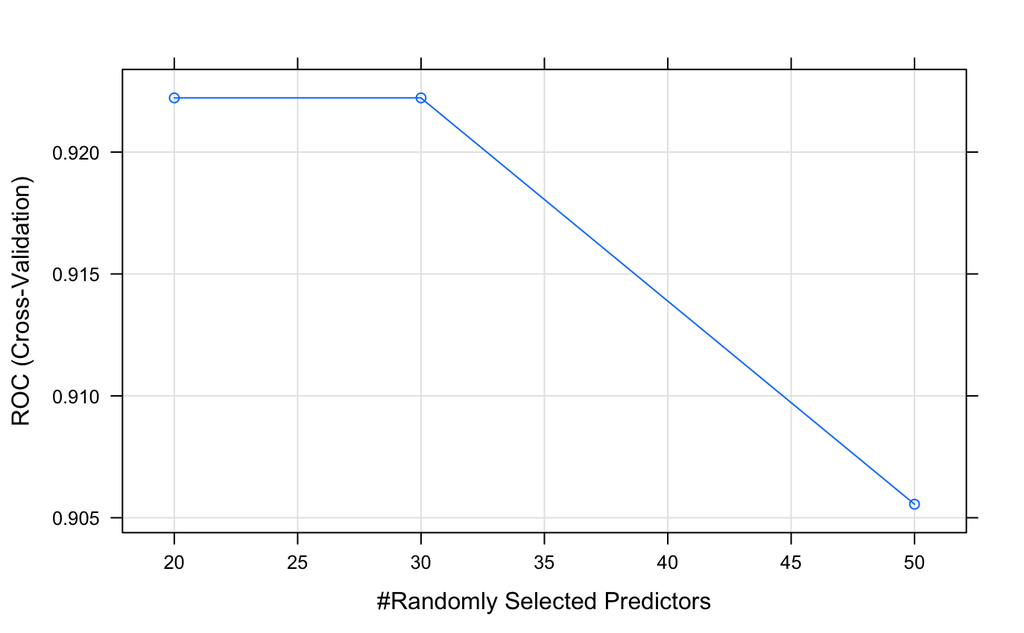

```r
plot(RF_50, metric = "ROC")
```

```r
## show the parameters that yield the most accurate classifier (as estimated by cv)
RF_50$bestTune
```

|  | mtry |
| --- | --- |
| 1 | 20 |

```r
#final model used and performance across test sets of each fold
RF_50$finalModel
```

```
Call:
 randomForest(x = x, y = y, mtry = param$mtry)
               Type of random forest: classification
                     Number of trees: 500
No. of variables tried at each split: 20

        OOB estimate of  error rate: 20.83%
Confusion matrix:
   g1 g3 class.error
g1 18  6   0.2500000
g3  4 20   0.1666667
```

```r
result <- featureSelect(CPM3_train, CPM3_train$grade == "g1", 100)
train_x <- data.frame(t(Biobase::exprs(result$dat)))
train_y <- result$dat$grade
fitControl <- trainControl(method="cv",
                           number=10,
                           classProbs=T,
                           summaryFunction=twoClassSummary)
RF_100 <- train(x=train_x,
             y=train_y,
             method="rf", # random forest
             trControl=fitControl,
             tuneGrid=expand.grid(mtry=c(20, 30, 50,100)),
             metric='ROC')
   #tuneGrid=expand.grid(mtry=c(32, 50, 100, 250, 500)),
```

```r
RF_100 <- train(x=train_x,
             y=train_y,
             method="rf", # random forest
             trControl=fitControl,
             tuneGrid=expand.grid(mtry=c(20,30, 50,100)),
             metric='ROC')
   #tuneGrid=expand.grid(mtry=c(32, 50, 100, 250, 500)),
RF_100
```

```
Random Forest

 48 samples
100 predictors
  2 classes: 'g1', 'g3'

No pre-processing
Resampling: Cross-Validated (10 fold)
Summary of sample sizes: 43, 42, 43, 43, 44, 44, ...
Resampling results across tuning parameters:

  mtry  ROC        Sens       Spec
   20   0.8666667  0.7166667  0.8833333
   30   0.8500000  0.7666667  0.7833333
   50   0.8500000  0.8000000  0.7833333
  100   0.8583333  0.7666667  0.7833333

ROC was used to select the optimal model using the largest value.
The final value used for the model was mtry = 20.
```

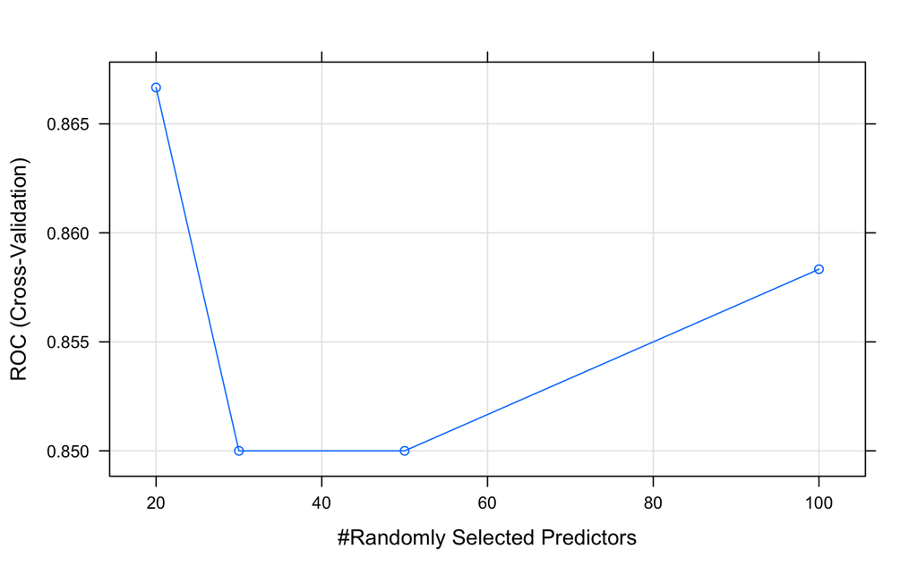

```r
plot(RF_100, metric = "ROC")
```

```r
## show the parameters that yield the most accurate classifier (as estimated by cv)
RF_100$bestTune
```

|  | mtry |
| --- | --- |
| 1 | 20 |

```r
#final model used and performance across test sets of each fold
RF_100$finalModel
```

```
Call:
 randomForest(x = x, y = y, mtry = param$mtry)
               Type of random forest: classification
                     Number of trees: 500
No. of variables tried at each split: 20

        OOB estimate of  error rate: 22.92%
Confusion matrix:
   g1 g3 class.error
g1 18  6   0.2500000
g3  5 19   0.2083333
```

```r
result <- featureSelect(CPM3_train, CPM3_train$grade == "g1", 500)
train_x <- data.frame(t(Biobase::exprs(result$dat)))
train_y <- result$dat$grade
fitControl <- trainControl(method="cv",
                           number=10,
                           classProbs=T,
                           summaryFunction=twoClassSummary)
RF_500 <- train(x=train_x,
             y=train_y,
             method="rf", # random forest
             trControl=fitControl,
             tuneGrid=expand.grid(mtry=c(20, 30, 50,100,500)),
             metric='ROC')
   #tuneGrid=expand.grid(mtry=c(32, 50, 100, 250, 500)),
```

```r
RF_500
```

```
Random Forest

 48 samples
500 predictors
  2 classes: 'g1', 'g3'

No pre-processing
Resampling: Cross-Validated (10 fold)
Summary of sample sizes: 44, 43, 44, 44, 42, 43, ...
Resampling results across tuning parameters:

  mtry  ROC        Sens       Spec
   20   0.8750000  0.6833333  0.8500000
   30   0.8416667  0.7333333  0.8166667
   50   0.8416667  0.6833333  0.8166667
  100   0.8583333  0.6833333  0.8500000
  500   0.8055556  0.6833333  0.8500000

ROC was used to select the optimal model using the largest value.
The final value used for the model was mtry = 20.
```

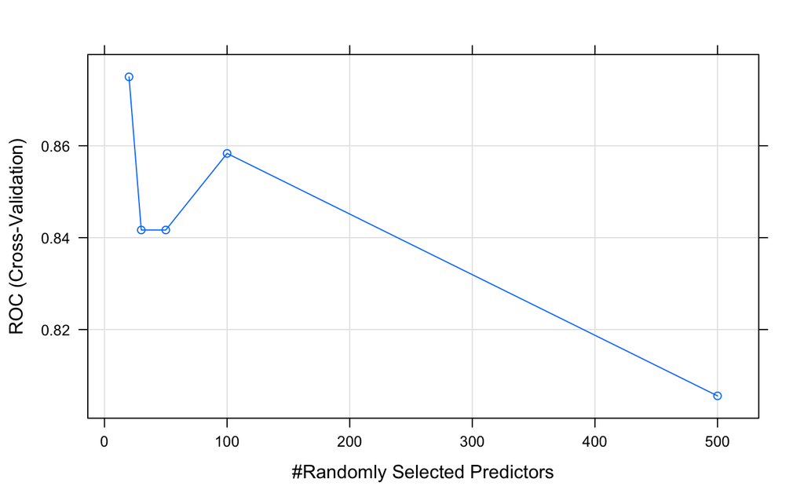

```r
plot(RF_500, metric = "ROC")
```

```r
## show the parameters that yield the most accurate classifier (as estimated by cv)
RF_500$bestTune
```

|  | mtry |
| --- | --- |
| 1 | 20 |

```r
#final model used and performance across test sets of each fold
RF_500$finalModel
```

```
Call:
 randomForest(x = x, y = y, mtry = param$mtry)
               Type of random forest: classification
                     Number of trees: 500
No. of variables tried at each split: 20

        OOB estimate of  error rate: 25%
Confusion matrix:
   g1 g3 class.error
g1 17  7   0.2916667
g3  5 19   0.2083333
```

```r
#CPM3_idx <- createDataPartition(CPM3_notAE$grade, p=0.6, list=FALSE, times=1)
#CPM3_train <- CPM3_notAE[, CPM3_idx]
#CPM3_test <- CPM3_notAE[, -CPM3_idx]
#test <-data.frame(t(Biobase::exprs(CPM3_test)))
#result1 <- featureSelect(CPM3_test, CPM3_test$grade == "g1", 500)
test_x <- data.frame(t(Biobase::exprs(CPM3_test)))
test_y <- CPM3_test$grade
#fitControl <- trainControl(method="cv",
                           #number=10,
                           #classProbs=T,
                           #summaryFunction=twoClassSummary)
## predicting the validation data:
predRF <- predict(RF_20,test_x)
## or predicting using the probabilities (nice because you can get ROC)
probsRF <- extractProb(list(model=RF_20),
                     testX=test_x,
                     testY=test_y)
## removing trainings data
probsRF <- probsRF[probsRF$dataType!='Training',]
## Make sure the levels are appropriate for twoClassSummary(), ie case group is first level
levs <- c("g1", "g3")
probsRF$obs <- factor(probsRF$obs, levels = levs)
probsRF$pred <- factor(probsRF$pred, levels = levs)
## Calculating Accuracy
mean(probsRF$obs==probsRF$pred)
```

```
[1] 0.8125
```

```r
###
#result <- featureSelect(CPM3_train, CPM3_train$grade == "g1", 20)
#train_x <- data.frame(t(Biobase::exprs(result$dat)))
#train_y <- result$dat$grade
#fitControl <- trainControl(method="cv",
                           #number=10,
                           #classProbs=T,
                           #summaryFunction=twoClassSummary)
```

```r
 ## see classification prob for each sample in validation set
## pred column shows model predicted label if cutoff for calling label = 0.5
table(probsRF$obs, probsRF$pred)
```

```
     g1 g3
  g1 13  3
  g3  3 13
```

```r
## summary of performance result on validation set
twoClassSummary(probsRF, lev = levels(probsRF$obs))
```

```
      ROC      Sens      Spec
0.8945312 0.8125000 0.8125000
```

```r
#result <- featureSelect(CPM3_train, CPM3_train$grade == "g1", RF_20) # not complete yet
```

###  
mine